# Baseline characteristics

Accompanying ‘CONVOCALS’

[Sander W. van der Laan, PhD](https://swvanderlaan.github.io) | @swvanderlaan | s.w.vanderlaan@gmail.com

2023-10-23

# General Setup

We will clean the environment, setup the locations, define colors, and create a datestamp.

*Clean the environment.*

*Set locations and working directories…*

```
Create a new analysis directories.

- general directory

- stains directory

- for plots

- for output of summary results

- for baseline tables
```

*… a package-installation function …*

```r
source("scripts/functions.R")
```

*… and load those packages.*

```r
source("scripts/pack01.packages.R")
```

```
* General packages...
```

*We will create a datestamp and define the Utrecht Science Park Colour Scheme*.

```r
Today = format(as.Date(as.POSIXlt(Sys.time())), "%Y%m%d")
Today.Report = format(as.Date(as.POSIXlt(Sys.time())), "%A, %B %d, %Y")

source("scripts/colors.R")
```

# This notebook

In this notebook we create a baseline table of the whole cohort and of the CEA-cohort.

# Athero-Express Biobank Study

The [*Athero-Express Biobank Study (AE)*](https://doi.org/10.1007/s10564-004-2304-6) contains plaque material of patients that underwent endarterectomyat two Dutch tertiary referral centers. Details of the study design were described before. Briefly, blood and plaque material were obtained during endarterectomy and stored at -80 ℃. Only carotid endarterectomy (CEA) patients were included in the present study. All patients provided informed consent and the study was approved by the medical ethics committee.

## Load data

Loading Athero-Express Biobank Study clinical and biobank data.

```r
cat("* get Athero-Express Biobank Study Database...")
```

```
* get Athero-Express Biobank Study Database...
```

```r
# METHOD 1: It seems this method gives loads of errors and warnings, which all are hard to comprehend
#           or debug. We expect 3,527 samples, and 927 variables; we get 927 variables!!!
# AEdata = as.data.table(read.spss(paste0(INP_loc,"/2017-1NEW_AtheroExpressDatabase_ScientificAE_20171306_v1.0.sav"),
#                                  trim.factor.names = TRUE, trim_values = TRUE, # we trim spaces in values
#                                  reencode = TRUE, # we re-encode to the local locale encoding
#                                  add.undeclared.levels = "append", # we do *not* want to convert to R-factors
#                                  use.value.labels = FALSE, # we do *not* convert variables with value labels into R factors
#                                  use.missings = TRUE, sub = "NA", # we will set every missing variable to NA
#                                  duplicated.value.labels = "condense", # we will condense duplicated value labels
#                                  to.data.frame = TRUE))
# AEdata.labels <- as.data.table(attr(AEdata, "variable.labels"))
# names(AEdata.labels) <- "Variable"

# METHOD 2: Using library("haven") importing seems flawless; best argument being:
#           we expect 3,527 samples and 888 variables, which is what you'd get with this method
#           So for now, METHOD 2 is prefered.
#
require(haven)

# AEDB <- haven::read_sav(paste0(AEDB_loc, "/2022_1_NEW_AtheroExpressDatabase_ScientificAE_15-02-2022.sav")) # something wrong with Age-variable
# AEDB <- haven::read_sav(paste0(AEDB_loc, "/2020_1_NEW_AtheroExpressDatabase_ScientificAE_16-03-2020.sav"))
# AEDB <- haven::read_sav(paste0(AEDB_loc, "/2020_1_NEW_AtheroExpressDatabase_ScientificAE_30-09-2020.sav")) # duplicate studynumbers in it
# AEDB <- haven::read_sav(paste0(AEDB_loc, "/2021_1_NEW_AtheroExpressDatabase_ScientificAE_01-02-2021.sav"))
# AEDB <- haven::read_sav(paste0(AEDB_loc, "/2021_3_NEW_AtheroExpressDatabase_ScientificAE_10-09-2021.sav"))
# AEDB <- haven::read_sav(paste0(AEDB_loc, "/2022_1_NEW_AtheroExpressDatabase_ScientificAE_11-02-2022.sav"))
# AEDB <- haven::read_sav(paste0(AEDB_loc, "/2022_1_NEW_AtheroExpressDatabase_ScientificAE_15-02-2022.sav"))
# AEDB <- haven::read_sav(paste0(AEDB_loc, "/2022_3_NEW_AtheroExpressDatabase_ScientificAE_27-09-2022.sav"))
AEDB <- haven::read_sav(paste0(AEDB_loc, "/2022_3_NEW_AtheroExpressDatabase_ScientificAE_withNewSymptoms_10-10-2022.sav"))

# writing off the SPSS data to an Excel.
# fwrite(AEdata, file = paste0(INP_loc,"/2017-1NEW_AtheroExpressDatabase_ScientificAE_20171306_v1.0.values.xlsx"),
#        sep = ";", na = "NA", dec = ".", col.names = TRUE, row.names = FALSE,
#        dateTimeAs = "ISO", showProgress = TRUE, verbose = TRUE)
# warnings()

AEDB[1:10, 1:10]
```

| STUDY_NUMBER | UPID | AE_AAA_bijzonderheden | informedconsent | writtenIC | EZis | date_ic_patient | date_ic_researcher | Hospital | Gender |
| --- | --- | --- | --- | --- | --- | --- | --- | --- | --- |
| 1 | UPID90067 | NA | 1 | 1 | NA | 2014-10-09 | 2014-08-15 | 1 | 1 |
| 2 | UPID01546 | NA | 1 | 1 | NA | 2002-04-02 | 2002-04-10 | 1 | 1 |
| 3 | UPID01241 | NA | 1 | 1 | NA | 2002-03-25 | 2002-04-21 | 1 | 1 |
| 4 | UPID01863 | NA | 1 | 1 | NA | 2002-03-31 | 2002-03-05 | 1 | 0 |
| 5 | UPID00636 | NA | 1 | 1 | NA | 2002-04-17 | 2002-04-17 | 1 | 1 |
| 6 | UPID00711 | NA | 1 | 1 | NA | 2002-04-03 | 2002-03-08 | 1 | 1 |
| 7 | UPID01636 | NA | 1 | 1 | NA | 2002-03-23 | 2002-03-28 | 1 | 1 |
| 8 | UPID01052 | NA | 1 | 1 | NA | 2002-04-16 | 2002-04-21 | 1 | 1 |
| 9 | UPID00918 | NA | 1 | 1 | NA | 2002-03-21 | 2002-04-22 | 1 | 1 |
| 10 | UPID01934 | NA | 30 | 0 | NA |  |  | 1 | 1 |

```r
dim(AEDB)
```

```
[1] 4016 1177
```

## Examine AEDB

We can examine the contents of the Athero-Express Biobank dataset to know what each variable is called, what class (type) it has, and what the variable description is.

There is an excellent post on this: https://www.r-bloggers.com/working-with-spss-labels-in-r/.

```r
AEDB %>% sjPlot::view_df(show.type = TRUE,
                         show.frq = TRUE,
                         show.prc = TRUE,
                         show.na = TRUE,
                         max.len = TRUE,
                         wrap.labels = 20,
                         verbose = FALSE,
                         use.viewer = FALSE,
                         file = paste0(OUT_loc, "/", Today, ".AEDB.dictionary.html"))
```

```
Following 3 variables have only missing values and are not shown:
```

```
yearpsy5 [464], yearchol3 [485], yearablo3 [557]
```

## Fixing and creating variables

We have to fix certain clinical parameters:

- symptoms
- diabetes
- alcohol use
- smoking
- plaque phenotypes

### Symptoms

We need to be very strict in defining *symptoms.* Therefore we will fix a new variable that groups *symptoms* at inclusion.

Coding of *symptoms* is as follows:

- missing -999
- Asymptomatic 0
- TIA 1
- minor stroke 2
- Major stroke 3
- Amaurosis fugax 4
- Four vessel disease 5
- Vertebrobasilary TIA 7
- Retinal infarction 8
- Symptomatic, but aspecific symtoms 9
- Contralateral symptomatic occlusion 10
- retinal infarction 11
- armclaudication due to occlusion subclavian artery, CEA needed for bypass 12
- retinal infarction + TIAs 13
- Ocular ischemic syndrome 14
- ischemisch glaucoom 15
- subclavian steal syndrome 16
- TGA 17

We will group as follows:

1. Asymptomatic > 0
2. TIA > 1, 7, 13
3. Stroke > 2, 3
4. Ocular > 4, 14, 15
5. Retinal infarction > 8, 11
6. Other > 5, 9, 10, 12, 16, 17

```r
# Fix symptoms
# AEDB$sympt
# value label
# <chr> <chr>
# -999  missing
# 0 Asymptomatic
# 1 TIA
# 2 minor stroke
# 3 Major stroke
# 4 Amaurosis fugax
# 5 Four vessel disease
# 7 Vertebrobasilary TIA
# 8 Retinal infarction
# 9 Symptomatic, but aspecific symtoms
# 10    Contralateral symptomatic occlusion
# 11    retinal infarction
# 12    armclaudication due to occlusion subclavian artery, CEA needed for bypass
# 13    retinal infarction + TIAs
# 14    Ocular ischemic syndrome
# 15    ischemisch glaucoom
# 16    subclavian steal syndrome
# 17    TGA

attach(AEDB)
AEDB[,"Symptoms.5G"] <- NA
AEDB$AsymptSympt[sympt == -999] <- NA
AEDB$Symptoms.5G[sympt == 0] <- "Asymptomatic"
AEDB$Symptoms.5G[sympt == 1 | sympt == 7 | sympt == 13] <- "TIA"
AEDB$Symptoms.5G[sympt == 2 | sympt == 3] <- "Stroke"
AEDB$Symptoms.5G[sympt == 4 |  sympt == 14 | sympt == 15 ] <- "Ocular"
AEDB$Symptoms.5G[sympt == 8 | sympt == 11] <- "Retinal infarction"
AEDB$Symptoms.5G[sympt == 5 | sympt == 9 | sympt == 10 | sympt == 12 | sympt == 16 | sympt == 17] <- "Other"

# AsymptSympt
AEDB[,"AsymptSympt"] <- NA
AEDB$AsymptSympt[sympt == -999] <- NA
AEDB$AsymptSympt[sympt == 0] <- "Asymptomatic"
AEDB$AsymptSympt[sympt == 1 | sympt == 7 | sympt == 13 | sympt == 2 | sympt == 3] <- "Symptomatic"
AEDB$AsymptSympt[sympt == 4 | sympt == 14 | sympt == 15 | sympt == 8 | sympt == 11 | sympt == 5 | sympt == 9 | sympt == 10 | sympt == 12 | sympt == 16 | sympt == 17] <- "Ocular and others"

# AsymptSympt
AEDB[,"AsymptSympt2G"] <- NA
AEDB$AsymptSympt2G[sympt == -999] <- NA
AEDB$AsymptSympt2G[sympt == 0] <- "Asymptomatic"
AEDB$AsymptSympt2G[sympt == 1 | sympt == 7 | sympt == 13 | sympt == 2 | sympt == 3 | sympt == 4 | sympt == 14 | sympt == 15 | sympt == 8 | sympt == 11 | sympt == 5 | sympt == 9 | sympt == 10 | sympt == 12 | sympt == 16 | sympt == 17] <- "Symptomatic"

detach(AEDB)

# table(AEDB$sympt, useNA = "ifany")
# table(AEDB$AsymptSympt2G, useNA = "ifany")
# table(AEDB$Symptoms.5G, useNA = "ifany")
#
table(AEDB$sympt, AEDB$AsymptSympt2G, useNA = "ifany")
```

```
       Asymptomatic Symptomatic <NA>
  0             353           0    0
  1               0        1095    0
  2               0         462    0
  3               0         315    0
  4               0         432    0
  5               0          43    0
  7               0           5    0
  8               0          40    0
  9               0          64    0
  10              0          12    0
  11              0           9    0
  12              0           1    0
  13              0           1    0
  14              0          29    0
  16              0           2    0
  <NA>            0           0 1153
```

```r
table(AEDB$sympt, AEDB$Symptoms.5G, useNA = "ifany")
```

```
       Asymptomatic Ocular Other Retinal infarction Stroke  TIA <NA>
  0             353      0     0                  0      0    0    0
  1               0      0     0                  0      0 1095    0
  2               0      0     0                  0    462    0    0
  3               0      0     0                  0    315    0    0
  4               0    432     0                  0      0    0    0
  5               0      0    43                  0      0    0    0
  7               0      0     0                  0      0    5    0
  8               0      0     0                 40      0    0    0
  9               0      0    64                  0      0    0    0
  10              0      0    12                  0      0    0    0
  11              0      0     0                  9      0    0    0
  12              0      0     1                  0      0    0    0
  13              0      0     0                  0      0    1    0
  14              0     29     0                  0      0    0    0
  16              0      0     2                  0      0    0    0
  <NA>            0      0     0                  0      0    0 1153
```

```r
table(AEDB$AsymptSympt2G,
      AEDB$Symptoms.5G, useNA = "ifany")
```

```
               Asymptomatic Ocular Other Retinal infarction Stroke  TIA <NA>
  Asymptomatic          353      0     0                  0      0    0    0
  Symptomatic             0    461   122                 49    777 1101    0
  <NA>                    0      0     0                  0      0    0 1153
```

```r
# AEDB.temp <- subset(AEDB,  select = c("STUDY_NUMBER", "UPID", "Age", "Gender", "Hospital", "Artery_summary", "sympt", "Symptoms.5G", "AsymptSympt"))
# require(labelled)
# AEDB.temp$Gender <- to_factor(AEDB.temp$Gender)
# AEDB.temp$Hospital <- to_factor(AEDB.temp$Hospital)
# AEDB.temp$Artery_summary <- to_factor(AEDB.temp$Artery_summary)
#
# DT::datatable(AEDB.temp[1:10,], caption = "Excerpt of the whole AEDB.", rownames = FALSE)
#
# table(AEDB.temp$Symptoms.5G, AEDB.temp$AsymptSympt)
#
# rm(AEDB.temp)
```

### Re-assessed symptoms

We re-assessed the categorization of symptoms. These are summarized and parsed in this section.

Labeling of new symptom categories.

```r
AEDB$indexsymptoms_worst
```

[output not shown]

| value | label |
| --- | --- |
| 0 | asymp |
| 1 | ocular |
| 2 | TIA |
| 3 | stroke |
| 9 | unclear |

```r
AEDB$indexsymptoms_worst_4g
```

[output not shown]

| value | label |
| --- | --- |
| 0 | asymp |
| 1 | ocular |
| 2 | TIA |
| 3 | stroke |
| 9 | unclear |

```r
AEDB$indexsymptoms_latest
```

[output not shown]

| value | label |
| --- | --- |
| 0 | asymp |
| 1 | ocular |
| 2 | TIA |
| 3 | stroke |
| 9 | unclear |

```r
AEDB$indexsymptoms_latest_4g
```

[output not shown]

| value | label |
| --- | --- |
| 0 | asymp |
| 1 | ocular |
| 2 | TIA |
| 3 | stroke |
| 9 | unclear |

Getting counts for each of the most important categories.

```r
cat("New 'worst' vs 'latest' symptom categories.\n")
```

```
New 'worst' vs 'latest' symptom categories.
```

```r
table(as_factor(AEDB$indexsymptoms_worst_4g), as_factor(AEDB$indexsymptoms_latest_4g))
```

```
          asymp ocular TIA stroke unclear
  asymp     823     62  84     25      25
  ocular      0    396   0      0       0
  TIA         0     19 761      0       1
  stroke      0      7  18    600       0
  unclear     0      0   0      0      55
```

```r
cat("\nNew 'worst' symptom categories.\n")
```

```
New 'worst' symptom categories.
```

```r
table((AEDB$indexsymptoms_worst_4g))
```

```
   0    1    2    3    9
1019  396  781  625   55
```

```r
cat("\nNew 'latest' symptom categories.\n")
```

```
New 'latest' symptom categories.
```

```r
table(as_factor(AEDB$indexsymptoms_latest_4g))
```

```
  asymp  ocular     TIA  stroke unclear
    823     484     863     625      81
```

Comparing with the original symptom categories.

```r
cat("New 'latest' vs original symptom 2G categories.\n")
```

```
New 'latest' vs original symptom 2G categories.
```

```r
table((AEDB$indexsymptoms_latest_4g), AEDB$AsymptSympt2G)
```

```
    Asymptomatic Symptomatic
  0          337         479
  1            2         481
  2            6         854
  3            1         621
  9            7          74
```

```r
cat("\nNew 'latest' vs original symptom 5G categories.\n")
```

```
New 'latest' vs original symptom 5G categories.
```

```r
table((AEDB$indexsymptoms_latest_4g), AEDB$Symptoms.5G)
```

```
    Asymptomatic Ocular Other Retinal infarction Stroke TIA
  0          337     79    82                  9    128 181
  1            2    358     4                 38     13  68
  2            6     11    19                  2     90 732
  3            1      2     7                  0    533  79
  9            7     11    10                  0     13  40
```

We need to be very strict in defining *symptoms.* Therefore we will fix a new variable that groups *symptoms* at inclusion.

Coding of *symptoms* is as follows:

- asympt 0
- ocular 1
- TIA 2
- stroke 3
- unclear 9

We will group as follows:

1. Asymptomatic > 0
2. Symptomatic > 1, 2, 3
3. NA > 9

```r
# Fix symptoms
attach(AEDB)

# Symptoms.Update2G
AEDB[,"Symptoms.Update2G"] <- NA
AEDB$Symptoms.Update2G[indexsymptoms_latest_4g == 0] <- "Asymptomatic"
AEDB$Symptoms.Update2G[indexsymptoms_latest_4g == 1 | indexsymptoms_latest_4g == 2 | indexsymptoms_latest_4g == 3] <- "Symptomatic"
AEDB$Symptoms.Update2G[indexsymptoms_latest_4g == 9 ] <- NA

# Symptoms.Update3G
AEDB[,"Symptoms.Update3G"] <- NA
AEDB$Symptoms.Update3G[indexsymptoms_latest_4g == 0] <- "Asymptomatic"
AEDB$Symptoms.Update3G[indexsymptoms_latest_4g == 1 | indexsymptoms_latest_4g == 2 | indexsymptoms_latest_4g == 3] <- "Symptomatic"
AEDB$Symptoms.Update3G[indexsymptoms_latest_4g == 9 ] <- "Unclear"

detach(AEDB)

table(AEDB$Symptoms.Update2G, AEDB$Symptoms.5G, useNA = "ifany")
```

```
               Asymptomatic Ocular Other Retinal infarction Stroke  TIA <NA>
  Asymptomatic          337     79    82                  9    128  181    7
  Symptomatic             9    371    30                 40    636  879    7
  <NA>                    7     11    10                  0     13   41 1139
```

```r
table(AEDB$Symptoms.Update3G, AEDB$Symptoms.5G, useNA = "ifany")
```

```
               Asymptomatic Ocular Other Retinal infarction Stroke  TIA <NA>
  Asymptomatic          337     79    82                  9    128  181    7
  Symptomatic             9    371    30                 40    636  879    7
  Unclear                 7     11    10                  0     13   40    0
  <NA>                    0      0     0                  0      0    1 1139
```

### Other clinical characteristics

We will also fix the *diabetes* status variable.

```r
# Fix diabetes
attach(AEDB)
AEDB[,"DiabetesStatus"] <- NA
AEDB$DiabetesStatus[DM.composite == -999] <- NA
AEDB$DiabetesStatus[DM.composite == 0] <- "Control (no Diabetes Dx/Med)"
AEDB$DiabetesStatus[DM.composite == 1] <- "Diabetes"
detach(AEDB)

table(AEDB$DM.composite, AEDB$DiabetesStatus)
```

```
    Control (no Diabetes Dx/Med) Diabetes
  0                         2956        0
  1                            0     1048
```

```r
# AEDB.temp <- subset(AEDB,  select = c("STUDY_NUMBER", "UPID", "Age", "Gender", "Hospital", "Artery_summary", "DM.composite", "DiabetesStatus"))
# require(labelled)
# AEDB.temp$Gender <- to_factor(AEDB.temp$Gender)
# AEDB.temp$Hospital <- to_factor(AEDB.temp$Hospital)
# AEDB.temp$Artery_summary <- to_factor(AEDB.temp$Artery_summary)
# AEDB.temp$DiabetesStatus <- to_factor(AEDB.temp$DiabetesStatus)
#
# DT::datatable(AEDB.temp[1:10,], caption = "Excerpt of the whole AEDB.", rownames = FALSE)
#
# rm(AEDB.temp)
```

We will also fix the *smoking* status variable. We are interested in whether someone never, ever or is currently (at the time of inclusion) smoking. This is based on the questionnaire.

- `diet801`: are you a smoker?
- `diet802`: did you smoke in the past?

We already have some variables indicating smoking status:

- `SmokingReported`: patient has reported to smoke.
- `SmokingYearOR`: smoking in the year of surgery?
- `SmokerCurrent`: currently smoking?

```r
require(labelled)
AEDB$diet801 <- to_factor(AEDB$diet801)
AEDB$diet802 <- to_factor(AEDB$diet802)
AEDB$diet805 <- to_factor(AEDB$diet805)
AEDB$SmokingReported <- to_factor(AEDB$SmokingReported)
AEDB$SmokerCurrent <- to_factor(AEDB$SmokerCurrent)
AEDB$SmokingYearOR <- to_factor(AEDB$SmokingYearOR)

# table(AEDB$diet801)
# table(AEDB$diet802)
# table(AEDB$SmokingReported)
# table(AEDB$SmokerCurrent)
# table(AEDB$SmokingYearOR)
# table(AEDB$SmokingReported, AEDB$SmokerCurrent, useNA = "ifany", dnn = c("Reported smoking", "Current smoker"))
#
# table(AEDB$diet801, AEDB$diet802, useNA = "ifany", dnn = c("Smoker", "Past smoker"))

cat("\nFixing smoking status.\n")
```

```
Fixing smoking status.
```

```r
attach(AEDB)
AEDB[,"SmokerStatus"] <- NA
AEDB$SmokerStatus[diet802 == "don't know"] <- "Never smoked"
AEDB$SmokerStatus[diet802 == "I still smoke"] <- "Current smoker"
AEDB$SmokerStatus[SmokerCurrent == "no" & diet802 == "no"] <- "Never smoked"
AEDB$SmokerStatus[SmokerCurrent == "no" & diet802 == "yes"] <- "Ex-smoker"
AEDB$SmokerStatus[SmokerCurrent == "yes"] <- "Current smoker"
AEDB$SmokerStatus[SmokerCurrent == "no data available/missing"] <- NA
# AEDB$SmokerStatus[is.na(SmokerCurrent)] <- "Never smoked"
detach(AEDB)

cat("\n* Current smoking status.\n")
```

```
* Current smoking status.
```

```r
table(AEDB$SmokerCurrent,
      useNA = "ifany",
      dnn = c("Current smoker"))
```

```
Current smoker
no data available/missing                        no                       yes                      <NA>
                        0                      2532                      1401                        83
```

```r
cat("\n* Updated smoking status.\n")
```

```
* Updated smoking status.
```

```r
table(AEDB$SmokerStatus,
      useNA = "ifany",
      dnn = c("Updated smoking status"))
```

```
Updated smoking status
Current smoker      Ex-smoker   Never smoked           <NA>
          1401           1941            426            248
```

```r
cat("\n* Comparing to 'SmokerCurrent'.\n")
```

```
* Comparing to 'SmokerCurrent'.
```

```r
table(AEDB$SmokerStatus, AEDB$SmokerCurrent,
      useNA = "ifany",
      dnn = c("Updated smoking status", "Current smoker"))
```

```
                      Current smoker
Updated smoking status no data available/missing   no  yes <NA>
        Current smoker                         0    0 1401    0
        Ex-smoker                              0 1941    0    0
        Never smoked                           0  426    0    0
        <NA>                                   0  165    0   83
```

```r
# AEDB.temp <- subset(AEDB,  select = c("STUDY_NUMBER", "UPID", "Age", "Gender", "Hospital", "Artery_summary", "DM.composite", "DiabetesStatus"))
# require(labelled)
# AEDB.temp$Gender <- to_factor(AEDB.temp$Gender)
# AEDB.temp$Hospital <- to_factor(AEDB.temp$Hospital)
# AEDB.temp$Artery_summary <- to_factor(AEDB.temp$Artery_summary)
# AEDB.temp$DiabetesStatus <- to_factor(AEDB.temp$DiabetesStatus)
#
# DT::datatable(AEDB.temp[1:10,], caption = "Excerpt of the whole AEDB.", rownames = FALSE)
#
# rm(AEDB.temp)
```

We will also fix the *alcohol* status variable.

```r
# Fix diabetes
attach(AEDB)
AEDB[,"AlcoholUse"] <- NA
AEDB$AlcoholUse[diet810 == -999] <- NA
AEDB$AlcoholUse[diet810 == 0] <- "No"
AEDB$AlcoholUse[diet810 == 1] <- "Yes"
detach(AEDB)

# AEDB.temp <- subset(AEDB,  select = c("STUDY_NUMBER", "UPID", "Age", "Gender", "Hospital", "Artery_summary", "diet810", "AlcoholUse"))
# require(labelled)
# AEDB.temp$Gender <- to_factor(AEDB.temp$Gender)
# AEDB.temp$Hospital <- to_factor(AEDB.temp$Hospital)
# AEDB.temp$Artery_summary <- to_factor(AEDB.temp$Artery_summary)
# AEDB.temp$AlcoholUse <- to_factor(AEDB.temp$AlcoholUse)
#
# DT::datatable(AEDB.temp[1:10,], caption = "Excerpt of the whole AEDB.", rownames = FALSE)
#
# rm(AEDB.temp)
```

We will also fix a history of CAD, stroke or peripheral intervention status variable. This will be based on `CAD_history`, `Stroke_history`, and `Peripheral.interv`

```r
# Fix diabetes
attach(AEDB)
AEDB[,"MedHx_CVD"] <- NA
AEDB$MedHx_CVD[CAD_history == 0 | Stroke_history == 0 | Peripheral.interv == 0] <- "No"
AEDB$MedHx_CVD[CAD_history == 1 | Stroke_history == 1 | Peripheral.interv == 1] <- "yes"
detach(AEDB)

table(AEDB$CAD_history)
```

```
   0    1
2616 1380
```

```r
table(AEDB$Stroke_history)
```

```
   0    1
2925 1003
```

```r
table(AEDB$Peripheral.interv)
```

```
   0    1
2771 1211
```

```r
table(AEDB$MedHx_CVD)
```

```
  No  yes
1343 2664
```

```r
# AEDB.temp <- subset(AEDB,  select = c("STUDY_NUMBER", "UPID", "Age", "Gender", "Hospital", "Artery_summary", "diet810", "AlcoholUse"))
# require(labelled)
# AEDB.temp$Gender <- to_factor(AEDB.temp$Gender)
# AEDB.temp$Hospital <- to_factor(AEDB.temp$Hospital)
# AEDB.temp$Artery_summary <- to_factor(AEDB.temp$Artery_summary)
# AEDB.temp$AlcoholUse <- to_factor(AEDB.temp$AlcoholUse)
#
# DT::datatable(AEDB.temp[1:10,], caption = "Excerpt of the whole AEDB.", rownames = FALSE)
#
# rm(AEDB.temp)
```

### Plaque phenotypes

We will also fix the *plaquephenotypes* variable.

Coding of symptoms is as follows:

- missing -999
- not relevant -888
- fibrous 1
- fibroatheromatous 2
- atheromatous 3

```r
# Fix plaquephenotypes
attach(AEDB)
AEDB[,"OverallPlaquePhenotype"] <- NA
AEDB$OverallPlaquePhenotype[plaquephenotype == -999] <- NA
AEDB$OverallPlaquePhenotype[plaquephenotype == -999] <- NA
AEDB$OverallPlaquePhenotype[plaquephenotype == 1] <- "fibrous"
AEDB$OverallPlaquePhenotype[plaquephenotype == 2] <- "fibroatheromatous"
AEDB$OverallPlaquePhenotype[plaquephenotype == 3] <- "atheromatous"
detach(AEDB)

# AEDB.temp <- subset(AEDB,  select = c("STUDY_NUMBER", "UPID", "Age", "Gender", "Hospital", "Artery_summary", "plaquephenotype", "OverallPlaquePhenotype"))
# require(labelled)
# AEDB.temp$Gender <- to_factor(AEDB.temp$Gender)
# AEDB.temp$Hospital <- to_factor(AEDB.temp$Hospital)
# AEDB.temp$Artery_summary <- to_factor(AEDB.temp$Artery_summary)
#
# DT::datatable(AEDB.temp[1:10,], caption = "Excerpt of the whole AEDB.", rownames = FALSE)
#
# rm(AEDB.temp)
```

We will also fix and inverse-rank normal transform the continuous (manually) scored plaque phenotypes.

```r
AEDB$macmean0 <- as.numeric(AEDB$macmean0)
AEDB$smcmean0 <- as.numeric(AEDB$smcmean0)
AEDB$neutrophils <- as.numeric(AEDB$neutrophils)
AEDB$Mast_cells_plaque <- as.numeric(AEDB$Mast_cells_plaque)
AEDB$vessel_density_averaged <- as.numeric(AEDB$vessel_density_averaged)

AEDB$MAC_rankNorm <- qnorm((rank(AEDB$macmean0, na.last = "keep") - 0.5) / sum(!is.na(AEDB$macmean0)))
AEDB$SMC_rankNorm <- qnorm((rank(AEDB$smcmean0, na.last = "keep") - 0.5) / sum(!is.na(AEDB$smcmean0)))
AEDB$Neutrophils_rankNorm <- qnorm((rank(AEDB$neutrophils, na.last = "keep") - 0.5) / sum(!is.na(AEDB$neutrophils)))
AEDB$MastCells_rankNorm <- qnorm((rank(AEDB$Mast_cells_plaque, na.last = "keep") - 0.5) / sum(!is.na(AEDB$Mast_cells_plaque)))
AEDB$VesselDensity_rankNorm <- qnorm((rank(AEDB$vessel_density_averaged, na.last = "keep") - 0.5) / sum(!is.na(AEDB$vessel_density_averaged)))
```

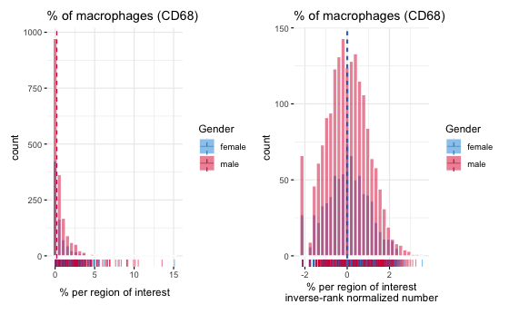

```r
library(labelled)
AEDB$Gender <- to_factor(AEDB$Gender)
library(patchwork)

p1 <- ggpubr::gghistogram(AEDB, "macmean0",
                    # y = "..count..",
                    color = "white",
                    fill = "Gender",
                    palette = c("#1290D9", "#DB003F"),
                    add = "median",
                    #add_density = TRUE,
                    rug = TRUE,
                    #add.params =  list(color = "black", linetype = 2),
                    title = "% of macrophages (CD68)",
                    xlab = "% per region of interest",
                    ggtheme = theme_minimal())
p2 <- ggpubr::gghistogram(AEDB, "MAC_rankNorm",
                    # y = "..count..",
                    color = "white",
                    fill = "Gender",
                    palette = c("#1290D9", "#DB003F"),
                    add = "median",
                    #add_density = TRUE,
                    rug = TRUE,
                    #add.params =  list(color = "black", linetype = 2),
                    title = "% of macrophages (CD68)",
                   xlab = "% per region of interest\ninverse-rank normalized number",
                    ggtheme = theme_minimal())
p1 | p2
```

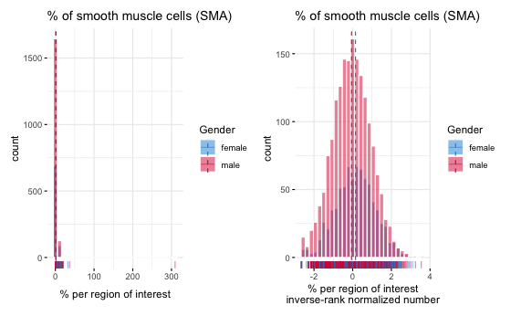

```r
p1 <- ggpubr::gghistogram(AEDB, "smcmean0",
                    # y = "..count..",
                    color = "white",
                    fill = "Gender",
                    palette = c("#1290D9", "#DB003F"),
                    add = "median",
                    #add_density = TRUE,
                    rug = TRUE,
                    #add.params =  list(color = "black", linetype = 2),
                    title = "% of smooth muscle cells (SMA)",
                    xlab = "% per region of interest",
                    ggtheme = theme_minimal())
p2 <- ggpubr::gghistogram(AEDB, "SMC_rankNorm",
                    # y = "..count..",
                    color = "white",
                    fill = "Gender",
                    palette = c("#1290D9", "#DB003F"),
                    add = "median",
                    #add_density = TRUE,
                    rug = TRUE,
                    #add.params =  list(color = "black", linetype = 2),
                    title = "% of smooth muscle cells (SMA)",
                   xlab = "% per region of interest\ninverse-rank normalized number",
                    ggtheme = theme_minimal())
p1 | p2
```

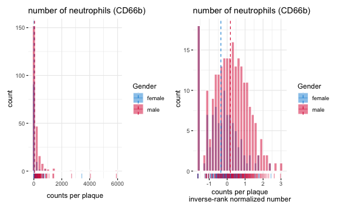

```r
p1 <- ggpubr::gghistogram(AEDB, "neutrophils",
                    # y = "..count..",
                    color = "white",
                    fill = "Gender",
                    palette = c("#1290D9", "#DB003F"),
                    add = "median",
                    #add_density = TRUE,
                    rug = TRUE,
                    #add.params =  list(color = "black", linetype = 2),
                    title = "number of neutrophils (CD66b)",
                    xlab = "counts per plaque",
                    ggtheme = theme_minimal())
p2 <- ggpubr::gghistogram(AEDB, "Neutrophils_rankNorm",
                    # y = "..count..",
                    color = "white",
                    fill = "Gender",
                    palette = c("#1290D9", "#DB003F"),
                    add = "median",
                    #add_density = TRUE,
                    rug = TRUE,
                    #add.params =  list(color = "black", linetype = 2),
                    title = "number of neutrophils (CD66b)",
                   xlab = "counts per plaque\ninverse-rank normalized number",
                    ggtheme = theme_minimal())
p1 | p2
```

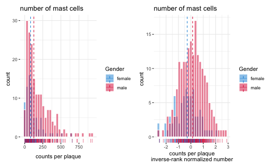

```r
p1 <- ggpubr::gghistogram(AEDB, "Mast_cells_plaque",
                    # y = "..count..",
                    color = "white",
                    fill = "Gender",
                    palette = c("#1290D9", "#DB003F"),
                    add = "median",
                    #add_density = TRUE,
                    rug = TRUE,
                    #add.params =  list(color = "black", linetype = 2),
                    title = "number of mast cells",
                    xlab = "counts per plaque",
                    ggtheme = theme_minimal())
p2 <- ggpubr::gghistogram(AEDB, "MastCells_rankNorm",
                    # y = "..count..",
                    color = "white",
                    fill = "Gender",
                    palette = c("#1290D9", "#DB003F"),
                    add = "median",
                    #add_density = TRUE,
                    rug = TRUE,
                    #add.params =  list(color = "black", linetype = 2),
                    title = "number of mast cells",
                   xlab = "counts per plaque\ninverse-rank normalized number",
                    ggtheme = theme_minimal())
p1 | p2
```

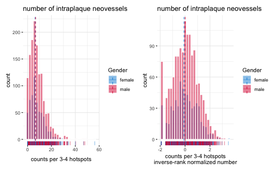

```r
p1 <- ggpubr::gghistogram(AEDB, "vessel_density_averaged",
                    # y = "..count..",
                    color = "white",
                    fill = "Gender",
                    palette = c("#1290D9", "#DB003F"),
                    add = "median",
                    #add_density = TRUE,
                    rug = TRUE,
                    #add.params =  list(color = "black", linetype = 2),
                    title = "number of intraplaque neovessels",
                    xlab = "counts per 3-4 hotspots",
                    ggtheme = theme_minimal())
p2 <- ggpubr::gghistogram(AEDB, "VesselDensity_rankNorm",
                    # y = "..count..",
                    color = "white",
                    fill = "Gender",
                    palette = c("#1290D9", "#DB003F"),
                    add = "median",
                    #add_density = TRUE,
                    rug = TRUE,
                    #add.params =  list(color = "black", linetype = 2),
                    title = "number of intraplaque neovessels",
                   xlab = "counts per 3-4 hotspots\ninverse-rank normalized number",
                    ggtheme = theme_minimal())
p1 | p2
```

```r
rm(p1, p2)
```

Here we calculate the *plaque instability/vulnerability* index

```r
# Plaque vulnerability
require(labelled)
AEDB$Macrophages.bin <- to_factor(AEDB$Macrophages.bin)
AEDB$SMC.bin <- to_factor(AEDB$SMC.bin)
AEDB$IPH.bin <- to_factor(AEDB$IPH.bin)
AEDB$Calc.bin <- to_factor(AEDB$Calc.bin)
AEDB$Collagen.bin <- to_factor(AEDB$Collagen.bin)
AEDB$Fat.bin_10 <- to_factor(AEDB$Fat.bin_10)
AEDB$Fat.bin_40 <- to_factor(AEDB$Fat.bin_40)

table(AEDB$Macrophages.bin)
```

```
      no/minor moderate/heavy
          1607           1220
```

```r
table(AEDB$Fat.bin_10)
```

```
 <10%  >10%
 1270  1708
```

```r
table(AEDB$Collagen.bin)
```

```
      no/minor moderate/heavy
           541           2306
```

```r
table(AEDB$SMC.bin)
```

```
      no/minor moderate/heavy
           874           1968
```

```r
table(AEDB$IPH.bin)
```

```
  no  yes
1223 1628
```

```r
# SPSS code

#
# *** syntax- Plaque vulnerability**.
# COMPUTE Macro_instab = -999.
# IF macrophages.bin=2 Macro_instab=1.
# IF macrophages.bin=1 Macro_instab=0.
# EXECUTE.
#
# COMPUTE Fat10_instab = -999.
# IF Fat.bin_10=2 Fat10_instab=1.
# IF Fat.bin_10=1 Fat10_instab=0.
# EXECUTE.
#
# COMPUTE coll_instab=-999.
# IF Collagen.bin=2 coll_instab=0.
# IF Collagen.bin=1 coll_instab=1.
# EXECUTE.
#
#
# COMPUTE SMC_instab=-999.
# IF SMC.bin=2 SMC_instab=0.
# IF SMC.bin=1 SMC_instab=1.
# EXECUTE.
#
# COMPUTE IPH_instab=-999.
# IF IPH.bin=0 IPH_instab=0.
# IF IPH.bin=1 IPH_instab=1.
# EXECUTE.
#
# COMPUTE Instability=Macro_instab + Fat10_instab +  coll_instab + SMC_instab + IPH_instab.
# EXECUTE.

# Fix plaquephenotypes
attach(AEDB)
# mac instability
AEDB[,"MAC_Instability"] <- NA
AEDB$MAC_Instability[Macrophages.bin == -999] <- NA
AEDB$MAC_Instability[Macrophages.bin == "no/minor"] <- 0
AEDB$MAC_Instability[Macrophages.bin == "moderate/heavy"] <- 1

# fat instability
AEDB[,"FAT10_Instability"] <- NA
AEDB$FAT10_Instability[Fat.bin_10 == -999] <- NA
AEDB$FAT10_Instability[Fat.bin_10 == " <10%"] <- 0
AEDB$FAT10_Instability[Fat.bin_10 == " >10%"] <- 1

# col instability
AEDB[,"COL_Instability"] <- NA
AEDB$COL_Instability[Collagen.bin == -999] <- NA
AEDB$COL_Instability[Collagen.bin == "no/minor"] <- 1
AEDB$COL_Instability[Collagen.bin == "moderate/heavy"] <- 0

# smc instability
AEDB[,"SMC_Instability"] <- NA
AEDB$SMC_Instability[SMC.bin == -999] <- NA
AEDB$SMC_Instability[SMC.bin == "no/minor"] <- 1
AEDB$SMC_Instability[SMC.bin == "moderate/heavy"] <- 0

# iph instability
AEDB[,"IPH_Instability"] <- NA
AEDB$IPH_Instability[IPH.bin == -999] <- NA
AEDB$IPH_Instability[IPH.bin == "no"] <- 0
AEDB$IPH_Instability[IPH.bin == "yes"] <- 1

detach(AEDB)

table(AEDB$MAC_Instability, useNA = "ifany")
```

```
   0    1 <NA>
1607 1220 1189
```

```r
table(AEDB$FAT10_Instability, useNA = "ifany")
```

```
   0    1 <NA>
1270 1708 1038
```

```r
table(AEDB$COL_Instability, useNA = "ifany")
```

```
   0    1 <NA>
2306  541 1169
```

```r
table(AEDB$SMC_Instability, useNA = "ifany")
```

```
   0    1 <NA>
1968  874 1174
```

```r
table(AEDB$IPH_Instability, useNA = "ifany")
```

```
   0    1 <NA>
1223 1628 1165
```

```r
# creating vulnerability index
AEDB <- AEDB %>% mutate(Plaque_Vulnerability_Index = factor(rowSums(.[grep("_Instability", names(.))], na.rm = TRUE)),
                                )

table(AEDB$Plaque_Vulnerability_Index, useNA = "ifany")
```

```
   0    1    2    3    4    5
1467  732  730  679  298  110
```

```r
# str(AEDB$Plaque_Vulnerability_Index)
```

## Fix biomarker

```r
AEDB$PCSK9_plasma <- as.numeric(AEDB$PCSK9_plasma)

AEDB$PCSK9_plasma_rankNorm <- qnorm((rank(AEDB$PCSK9_plasma, na.last = "keep") - 0.5) / sum(!is.na(AEDB$PCSK9_plasma)))
```

[figure not shown]

```r
library(labelled)
AEDB$Gender <- to_factor(AEDB$Gender)
library(patchwork)

p1 <- ggpubr::gghistogram(AEDB, "PCSK9_plasma",
                    # y = "..count..",
                    color = "white",
                    fill = "Gender",
                    palette = c("#1290D9", "#DB003F"),
                    add = "median",
                    #add_density = TRUE,
                    rug = TRUE,
                    #add.params =  list(color = "black", linetype = 2),
                    title = "PCSK9 in citrate plasma (pg/ml), measured by Luminex",
                    xlab = "PCSK9 in citrate plasma (pg/ml), measured by Luminex",
                    ggtheme = theme_minimal())
p2 <- ggpubr::gghistogram(AEDB, "PCSK9_plasma_rankNorm",
                    # y = "..count..",
                    color = "white",
                    fill = "Gender",
                    palette = c("#1290D9", "#DB003F"),
                    add = "median",
                    #add_density = TRUE,
                    rug = TRUE,
                    #add.params =  list(color = "black", linetype = 2),
                    title = "PCSK9 in citrate plasma (pg/ml), measured by Luminex",
                   xlab = "PCSK9 in citrate plasma (pg/ml), measured by Luminex\ninverse-rank normalized number",
                    ggtheme = theme_minimal())
p1 | p2
```

## Prepare baseline summary

We are interested in the following variables at baseline.

- Age (years)
- Female sex (N, %)
- Hypertension (N, %)
- SBP (mmHg)
- DBP (mmHg)
- Diabetes mellitus (N, %)
- Total cholesterol levels (mg/dL)
- LDL cholesterol levels (mg/dL)
- HDL cholesterol levels (mg/dL)
- Triglyceride levels (mg/dL)
- Use of statins (N, %)
- Use of antiplatelet drugs (N, %)
- BMI (kg/m²)
- Smoking status (N, %)
  - Never smokers
  - Ex-smokers
  - Current smokers
- History of CAD (N, %)
- History of PAD (N, %)
- Clinical manifestations
  - Asymptomatic
  - Amaurosis fugax
  - TIA
  - Stroke
- eGFR (mL/min/1.73 m²)
- stenosis
- year of surgery
- plaque characteristics

```r
cat("====================================================================================================\n")
cat("SELECTION THE SHIZZLE\n")
```

```
SELECTION THE SHIZZLE
```

```r
### Artery levels
# AEdata$Artery_summary:
#           value                                                                                   label
# NOT USE - 0 No artery known (yet), no surgery (patient ill, died, exited study), re-numbered to AAA
# USE - 1                                                                  carotid (left & right)
# USE - 2                                               femoral/iliac (left, right or both sides)
# NOT USE - 3                                               other carotid arteries (common, external)
# NOT USE - 4                                   carotid bypass and injury (left, right or both sides)
# NOT USE - 5                                                         aneurysmata (carotid & femoral)
# NOT USE - 6                                                                                   aorta
# NOT USE - 7                                            other arteries (renal, popliteal, vertebral)
# NOT USE - 8                        femoral bypass, angioseal and injury (left, right or both sides)

### AEdata$informedconsent
#           value                                                                                           label
# NOT USE - -999                                                                                         missing
# NOT USE - 0                                                                                        no, died
# USE - 1                                                                                             yes
# USE - 2                                                             yes, health treatment when possible
# USE - 3                                                                        yes, no health treatment
# USE - 4                                                yes, no health treatment, no commercial business
# NOT USE - 5                                                          yes, no tissue, no commerical business
# NOT USE - 6                      yes, no tissue, no questionnaires, no medical info, no commercial business
# USE - 7                             yes, no questionnaires, no health treatment, no commercial business
# USE - 8                                          yes, no questionnaires, health treatment when possible
# NOT USE - 9                  yes, no tissue, no questionnaires, no health treatment, no commerical business
# USE - 10                               yes, no health treatment, no medical info, no commercial business
# NOT USE - 11 yes, no tissue, no questionnaires, no health treatment, no medical info, no commercial business
# USE - 12                                                     yes, no questionnaires, no health treatment
# NOT USE - 13                                                             yes, no tissue, no health treatment
# NOT USE - 14                                                               yes, no tissue, no questionnaires
# NOT USE - 15                                                  yes, no tissue, health treatment when possible
# NOT USE - 16                                                                                  yes, no tissue
# USE - 17                                                                     yes, no commerical business
# USE - 18                                     yes, health treatment when possible, no commercial business
# USE - 19                                                    yes, no medical info, no commercial business
# USE - 20                                                                          yes, no questionnaires
# NOT USE - 21                         yes, no tissue, no questionnaires, no health treatment, no medical info
# NOT USE - 22                  yes, no tissue, no questionnaires, no health treatment, no commercial business
# USE - 23                                                                            yes, no medical info
# USE - 24                                                  yes, no questionnaires, no commercial business
# USE - 25                                    yes, no questionnaires, no health treatment, no medical info
# USE - 26                  yes, no questionnaires, health treatment when possible, no commercial business
# USE - 27                                                      yes,  no health treatment, no medical info
# NOT USE - 28                                                                             no, doesn't want to
# NOT USE - 29                                                                              no, unable to sign
# NOT USE - 30                                                                                 no, no reaction
# NOT USE - 31                                                                                        no, lost
# NOT USE - 32                                                                                     no, too old
# NOT USE - 34                                            yes, no medical info, health treatment when possible
# NOT USE - 35                                             no (never asked for IC because there was no tissue)
# USE - 36                    yes, no medical info, no commercial business, health treatment when possible
# NOT USE - 37                                                                                    no, endpoint
# USE - 38                                                         wil niets invullen, wel alles gebruiken
# USE - 39                                           second informed concents: yes, no commercial business
# NOT USE - 40                                                                              nooit geincludeerd

cat("- sanity checking PRIOR to selection")
```

```
- sanity checking PRIOR to selection
```

```r
library(data.table)
require(labelled)
ae.gender <- to_factor(AEDB$Gender)
ae.hospital <- to_factor(AEDB$Hospital)
table(ae.gender, ae.hospital, dnn = c("Sex", "Hospital"))
```

```
        Hospital
Sex      St. Antonius, Nieuwegein UMC Utrecht
  female                      524         702
  male                       1211        1579
```

```r
ae.artery <- to_factor(AEDB$Artery_summary)
table(ae.artery, ae.gender, dnn = c("Sex", "Artery"))
```

```
                                                                                         Artery
Sex                                                                                       female male
  No artery known (yet), no surgery (patient ill, died, exited study), re-numbered to AAA      0    0
  carotid (left & right)                                                                     858 1901
  femoral/iliac (left, right or both sides)                                                  333  835
  other carotid arteries (common, external)                                                   17   34
  carotid bypass and injury (left, right or both sides)                                        6    3
  aneurysmata (carotid & femoral)                                                              1    1
  aorta                                                                                        3    5
  other arteries (renal, popliteal, vertebral)                                                 4    9
  femoral bypass, angioseal and injury (left, right or both sides)                             4    2
```

```r
rm(ae.gender, ae.hospital, ae.artery)

# I change numeric and factors manually because, well, I wouldn't know how to fix it otherwise
# to have this 'tibble' work with 'tableone'... :-)

AEDB$Age <- as.numeric(AEDB$Age)
AEDB$diastoli <- as.numeric(AEDB$diastoli)
AEDB$systolic <- as.numeric(AEDB$systolic)

AEDB$TC_finalCU <- as.numeric(AEDB$TC_finalCU)
AEDB$LDL_finalCU <- as.numeric(AEDB$LDL_finalCU)
AEDB$HDL_finalCU <- as.numeric(AEDB$HDL_finalCU)
AEDB$TG_finalCU <- as.numeric(AEDB$TG_finalCU)

AEDB$TC_final <- as.numeric(AEDB$TC_final)
AEDB$LDL_final <- as.numeric(AEDB$LDL_final)
AEDB$HDL_final <- as.numeric(AEDB$HDL_final)
AEDB$TG_final <- as.numeric(AEDB$TG_final)

AEDB$Age <- as.numeric(AEDB$Age)
AEDB$GFR_MDRD <- as.numeric(AEDB$GFR_MDRD)
AEDB$BMI <- as.numeric(AEDB$BMI)
AEDB$eCigarettes <- as.numeric(AEDB$eCigarettes)
AEDB$ePackYearsSmoking <- as.numeric(AEDB$ePackYearsSmoking)
AEDB$EP_composite_time <- as.numeric(AEDB$EP_composite_time)
AEDB$EP_major_time <- as.numeric(AEDB$EP_major_time)

AEDB$PCSK9_plasma <- as.numeric(AEDB$PCSK9_plasma)
AEDB$PCSK9_plasma_rankNorm <- as.numeric(AEDB$PCSK9_plasma_rankNorm)

require(labelled)
AEDB$ORyear <- to_factor(AEDB$ORyear)
AEDB$Gender <- to_factor(AEDB$Gender)
AEDB$Hospital <- to_factor(AEDB$Hospital)
AEDB$KDOQI <- to_factor(AEDB$KDOQI)
AEDB$BMI_WHO <- to_factor(AEDB$BMI_WHO)
AEDB$DiabetesStatus <- to_factor(AEDB$DiabetesStatus)
AEDB$SmokerStatus <- to_factor(AEDB$SmokerStatus)
AEDB$AlcoholUse <- to_factor(AEDB$AlcoholUse)

AEDB$Hypertension.selfreport <- to_factor(AEDB$Hypertension1)
AEDB$Hypertension.selfreportdrug <- to_factor(AEDB$Hypertension2)
AEDB$Hypertension.composite <- to_factor(AEDB$Hypertension.composite)
AEDB$Hypertension.drugs <- to_factor(AEDB$Hypertension.drugs)

AEDB$Med.anticoagulants <- to_factor(AEDB$Med.anticoagulants)
AEDB$Med.all.antiplatelet <- to_factor(AEDB$Med.all.antiplatelet)
AEDB$Med.Statin.LLD <- to_factor(AEDB$Med.Statin.LLD)

AEDB$Stroke_Dx <- to_factor(AEDB$Stroke_Dx)
AEDB$CAD_history <- to_factor(AEDB$CAD_history)
AEDB$PAOD <- to_factor(AEDB$PAOD)
AEDB$Peripheral.interv <- to_factor(AEDB$Peripheral.interv)

AEDB$sympt <- to_factor(AEDB$sympt)
AEDB$Symptoms.3g <- to_factor(AEDB$Symptoms.3g)
AEDB$Symptoms.4g <- to_factor(AEDB$Symptoms.4g)
AEDB$Symptoms.5G <- to_factor(AEDB$Symptoms.5G)
AEDB$AsymptSympt <- to_factor(AEDB$AsymptSympt)
AEDB$AsymptSympt2G <- to_factor(AEDB$AsymptSympt2G)
AEDB$indexsymptoms_latest_4g <- to_factor(AEDB$indexsymptoms_latest_4g)
AEDB$Symptoms.Update2G <- to_factor(AEDB$Symptoms.Update2G)
AEDB$Symptoms.Update3G <- to_factor(AEDB$Symptoms.Update3G)

AEDB$restenos <- to_factor(AEDB$restenos)
AEDB$stenose <- to_factor(AEDB$stenose)
AEDB$EP_composite <- to_factor(AEDB$EP_composite)
AEDB$EP_major <- to_factor(AEDB$EP_major)
AEDB$Macrophages.bin <- to_factor(AEDB$Macrophages.bin)
AEDB$SMC.bin <- to_factor(AEDB$SMC.bin)
AEDB$IPH.bin <- to_factor(AEDB$IPH.bin)
AEDB$Calc.bin <- to_factor(AEDB$Calc.bin)
AEDB$Collagen.bin <- to_factor(AEDB$Collagen.bin)
AEDB$Fat.bin_10 <- to_factor(AEDB$Fat.bin_10)
AEDB$Fat.bin_40 <- to_factor(AEDB$Fat.bin_40)
AEDB$OverallPlaquePhenotype <- to_factor(AEDB$OverallPlaquePhenotype)
AEDB$Plaque_Vulnerability_Index <- to_factor(AEDB$Plaque_Vulnerability_Index)

AEDB$Artery_summary <- to_factor(AEDB$Artery_summary)

AEDB$informedconsent <- to_factor(AEDB$informedconsent)

AEDB.CEA <- subset(AEDB,
                    (Artery_summary == "carotid (left & right)" | Artery_summary == "other carotid arteries (common, external)") & # we only want carotids
                       informedconsent != "missing" & # we are really strict in selecting based on 'informed consent'!
                       informedconsent != "no, died" &
                       informedconsent != "yes, no tissue, no commerical business" &
                       informedconsent != "yes, no tissue, no questionnaires, no medical info, no commercial business" &
                       informedconsent != "yes, no tissue, no questionnaires, no health treatment, no commerical business" &
                       informedconsent != "yes, no tissue, no questionnaires, no health treatment, no medical info, no commercial business" &
                       informedconsent != "yes, no tissue, no health treatment" &
                       informedconsent != "yes, no tissue, no questionnaires" &
                       informedconsent != "yes, no tissue, health treatment when possible" &
                       informedconsent != "yes, no tissue" &
                       informedconsent != "yes, no tissue, no questionnaires, no health treatment, no medical info" &
                       informedconsent != "yes, no tissue, no questionnaires, no health treatment, no commercial business" &
                       informedconsent != "no, doesn't want to" &
                       informedconsent != "no, unable to sign" &
                       informedconsent != "no, no reaction" &
                       informedconsent != "no, lost" &
                       informedconsent != "no, too old" &
                       informedconsent != "yes, no medical info, health treatment when possible" &
                       informedconsent != "no (never asked for IC because there was no tissue)" &
                       informedconsent != "no, endpoint" &
                       informedconsent != "nooit geincludeerd" &
                     !is.na(AsymptSympt2G))
# AEDB.CEA[1:10, 1:10]
dim(AEDB.CEA)
```

```
[1] 2585 1201
```

```r
AEDB.full <- subset(AEDB,
                    informedconsent != "missing" & # we are really strict in selecting based on 'informed consent'!
                       informedconsent != "no, died" &
                       informedconsent != "yes, no tissue, no commerical business" &
                       informedconsent != "yes, no tissue, no questionnaires, no medical info, no commercial business" &
                       informedconsent != "yes, no tissue, no questionnaires, no health treatment, no commerical business" &
                       informedconsent != "yes, no tissue, no questionnaires, no health treatment, no medical info, no commercial business" &
                       informedconsent != "yes, no tissue, no health treatment" &
                       informedconsent != "yes, no tissue, no questionnaires" &
                       informedconsent != "yes, no tissue, health treatment when possible" &
                       informedconsent != "yes, no tissue" &
                       informedconsent != "yes, no tissue, no questionnaires, no health treatment, no medical info" &
                       informedconsent != "yes, no tissue, no questionnaires, no health treatment, no commercial business" &
                       informedconsent != "no, doesn't want to" &
                       informedconsent != "no, unable to sign" &
                       informedconsent != "no, no reaction" &
                       informedconsent != "no, lost" &
                       informedconsent != "no, too old" &
                       informedconsent != "yes, no medical info, health treatment when possible" &
                       informedconsent != "no (never asked for IC because there was no tissue)" &
                       informedconsent != "no, endpoint" &
                       informedconsent != "nooit geincludeerd")
# AEDB.CEA[1:10, 1:10]
dim(AEDB.full)
```

```
[1] 3678 1201
```

```r
cat("===========================================================================================\n")
cat("CREATE BASELINE TABLE\n")
```

```
CREATE BASELINE TABLE
```

```r
# Baseline table variables
basetable_vars = c("Hospital", "ORyear",
                   "Age", "Gender",
                   # "TC_finalCU", "LDL_finalCU", "HDL_finalCU", "TG_finalCU",
                   "TC_final", "LDL_final", "HDL_final", "TG_final",
                   # "hsCRP_plasma",
                   "systolic", "diastoli", "GFR_MDRD", "BMI",
                   "KDOQI", "BMI_WHO",
                   "SmokerStatus", "AlcoholUse",
                   "DiabetesStatus",
                   "Hypertension.selfreport", "Hypertension.selfreportdrug", "Hypertension.composite", "Hypertension.drugs",
                   "Med.anticoagulants", "Med.all.antiplatelet", "Med.Statin.LLD",
                   "Stroke_Dx", "sympt", "Symptoms.5G", "AsymptSympt", "AsymptSympt2G",
                   "indexsymptoms_latest_4g", "Symptoms.Update2G", "Symptoms.Update3G",
                   "restenos", "stenose",
                   "CAD_history", "PAOD", "Peripheral.interv",
                   "EP_composite", "EP_composite_time", "EP_major", "EP_major_time",
                   "MAC_rankNorm", "SMC_rankNorm", "Macrophages.bin", "SMC.bin",
                   "Neutrophils_rankNorm", "MastCells_rankNorm",
                   "IPH.bin", "VesselDensity_rankNorm",
                   "Calc.bin", "Collagen.bin",
                   "Fat.bin_10", "Fat.bin_40",
                   "OverallPlaquePhenotype", "Plaque_Vulnerability_Index",
                   "PCSK9_plasma", "PCSK9_plasma_rankNorm")

basetable_bin = c("Gender",
                  "KDOQI", "BMI_WHO",
                  "SmokerStatus", "AlcoholUse",
                  "DiabetesStatus",
                  "Hypertension.selfreport", "Hypertension.selfreportdrug", "Hypertension.composite", "Hypertension.drugs",
                  "Med.anticoagulants", "Med.all.antiplatelet", "Med.Statin.LLD",
                  "Stroke_Dx", "sympt", "Symptoms.5G", "AsymptSympt", "AsymptSympt2G",
                  "indexsymptoms_latest_4g", "Symptoms.Update2G", "Symptoms.Update3G",
                  "restenos", "stenose",
                  "CAD_history", "PAOD", "Peripheral.interv",
                  "EP_composite", "Macrophages.bin", "SMC.bin",
                  "IPH.bin",
                  "Calc.bin", "Collagen.bin",
                  "Fat.bin_10", "Fat.bin_40",
                  "OverallPlaquePhenotype", "Plaque_Vulnerability_Index")
# basetable_bin

basetable_con = basetable_vars[!basetable_vars %in% basetable_bin]
# basetable_con
```

# Athero-Express Biobank Study Baseline Characteristics

Showing the baseline table of the whole Athero-Express Biobank.

```r
# Create baseline tables
# http://rstudio-pubs-static.s3.amazonaws.com/13321_da314633db924dc78986a850813a50d5.html
AEDB.tableOne = print(CreateTableOne(vars = basetable_vars,
                                         # factorVars = basetable_bin,
                                         # strata = "Symptoms.4g",
                                         data = AEDB.full, includeNA = TRUE),
                          nonnormal = c(), missing = TRUE,
                          quote = FALSE, noSpaces = FALSE, showAllLevels = TRUE, explain = TRUE,
                          format = "pf",
                          contDigits = 3)[,1:3]
```

```
                                       level                                                                     Overall               Missing
  n                                                                                                                   3678
  Hospital % (freq)                    St. Antonius, Nieuwegein                                                       42.6 (1567)       0.0
                                       UMC Utrecht                                                                    57.4 (2111)
  ORyear % (freq)                      No data available/missing                                                       0.0 (   0)       0.0
                                       2002                                                                            2.3 (  86)
                                       2003                                                                            5.2 ( 191)
                                       2004                                                                            7.2 ( 265)
                                       2005                                                                            7.5 ( 276)
                                       2006                                                                            6.9 ( 254)
                                       2007                                                                            5.6 ( 206)
                                       2008                                                                            5.2 ( 190)
                                       2009                                                                            6.7 ( 246)
                                       2010                                                                            7.6 ( 278)
                                       2011                                                                            6.6 ( 243)
                                       2012                                                                            7.7 ( 284)
                                       2013                                                                            6.4 ( 235)
                                       2014                                                                            7.6 ( 281)
                                       2015                                                                            2.1 (  77)
                                       2016                                                                            3.3 ( 121)
                                       2017                                                                            2.2 (  81)
                                       2018                                                                            2.2 (  82)
                                       2019                                                                            2.3 (  86)
                                       2020                                                                            1.8 (  68)
                                       2021                                                                            2.3 (  86)
                                       2022                                                                            1.1 (  42)
  Age (mean (SD))                                                                                                   68.859 (9.229)      0.0
  Gender % (freq)                      female                                                                         29.7 (1091)       0.0
                                       male                                                                           70.3 (2587)
  TC_final (mean (SD))                                                                                               4.813 (2.687)     45.5
  LDL_final (mean (SD))                                                                                              2.748 (1.180)     52.8
  HDL_final (mean (SD))                                                                                              1.368 (6.817)     49.6
  TG_final (mean (SD))                                                                                               1.752 (1.124)     50.4
  systolic (mean (SD))                                                                                             150.299 (24.652)    12.3
  diastoli (mean (SD))                                                                                              79.811 (21.916)    12.3
  GFR_MDRD (mean (SD))                                                                                              75.309 (24.780)     6.0
  BMI (mean (SD))                                                                                                   26.415 (4.117)      3.7
  KDOQI % (freq)                       No data available/missing                                                       0.0 (   0)       6.0
                                       Normal kidney function                                                         22.5 ( 829)
                                       CKD 2 (Mild)                                                                   47.7 (1756)
```

[output cut: 158 more lines]

```
  Fat.bin_40 % (freq)                  <40%                                                                           58.0 (2132)      26.5
                                       >40%                                                                           15.5 ( 571)
                                       <NA>                                                                           26.5 ( 975)
  OverallPlaquePhenotype % (freq)      atheromatous                                                                   15.0 ( 550)      27.1
                                       fibroatheromatous                                                              21.9 ( 806)
                                       fibrous                                                                        36.0 (1324)
                                       <NA>                                                                           27.1 ( 998)
  Plaque_Vulnerability_Index % (freq)  0                                                                              36.8 (1353)       0.0
                                       1                                                                              18.1 ( 666)
                                       2                                                                              17.9 ( 658)
                                       3                                                                              17.0 ( 624)
                                       4                                                                               7.5 ( 277)
                                       5                                                                               2.7 ( 100)
  PCSK9_plasma (mean (SD))                                                                                       31932.936 (18395.193) 61.6
  PCSK9_plasma_rankNorm (mean (SD))                                                                                 -0.002 (1.004)     61.6
```

```r
# Create baseline tables
# http://rstudio-pubs-static.s3.amazonaws.com/13321_da314633db924dc78986a850813a50d5.html
AEDB.CEA.tableOne = print(CreateTableOne(vars = basetable_vars,
                                         # factorVars = basetable_bin,
                                         # strata = "Symptoms.4g",
                                         data = AEDB.CEA, includeNA = TRUE),
                          nonnormal = c(), missing = TRUE,
                          quote = FALSE, noSpaces = FALSE, showAllLevels = TRUE, explain = TRUE,
                          format = "pf",
                          contDigits = 3)[,1:3]
```

```
                                       level                                                                     Overall               Missing
  n                                                                                                                   2585
  Hospital % (freq)                    St. Antonius, Nieuwegein                                                       36.7 ( 948)       0.0
                                       UMC Utrecht                                                                    63.3 (1637)
  ORyear % (freq)                      No data available/missing                                                       0.0 (   0)       0.0
                                       2002                                                                            3.1 (  81)
                                       2003                                                                            6.1 ( 157)
                                       2004                                                                            7.4 ( 190)
                                       2005                                                                            7.2 ( 185)
                                       2006                                                                            7.1 ( 183)
                                       2007                                                                            5.9 ( 152)
                                       2008                                                                            5.3 ( 138)
                                       2009                                                                            7.0 ( 181)
                                       2010                                                                            6.2 ( 159)
                                       2011                                                                            6.3 ( 163)
                                       2012                                                                            6.8 ( 176)
                                       2013                                                                            5.8 ( 149)
                                       2014                                                                            6.3 ( 163)
                                       2015                                                                            2.9 (  76)
                                       2016                                                                            3.3 (  85)
                                       2017                                                                            2.6 (  66)
                                       2018                                                                            2.7 (  69)
                                       2019                                                                            2.6 (  66)
                                       2020                                                                            2.1 (  53)
                                       2021                                                                            2.5 (  65)
                                       2022                                                                            1.1 (  28)
  Age (mean (SD))                                                                                                   69.228 (9.324)      0.0
  Gender % (freq)                      female                                                                         30.4 ( 787)       0.0
                                       male                                                                           69.6 (1798)
  TC_final (mean (SD))                                                                                               4.751 (1.437)     37.3
  LDL_final (mean (SD))                                                                                              2.791 (1.219)     44.5
  HDL_final (mean (SD))                                                                                              1.204 (0.434)     40.8
  TG_final (mean (SD))                                                                                               1.717 (1.040)     41.8
  systolic (mean (SD))                                                                                             151.749 (24.785)    10.7
  diastoli (mean (SD))                                                                                              80.942 (24.526)    10.7
  GFR_MDRD (mean (SD))                                                                                              73.684 (21.726)     4.1
  BMI (mean (SD))                                                                                                   26.526 (4.112)      3.7
  KDOQI % (freq)                       No data available/missing                                                       0.0 (   0)       4.1
                                       Normal kidney function                                                         20.3 ( 524)
                                       CKD 2 (Mild)                                                                   51.0 (1318)
```

[output cut: 154 more lines]

```
  Fat.bin_40 % (freq)                  <40%                                                                           53.7 (1388)      26.6
                                       >40%                                                                           19.7 ( 510)
                                       <NA>                                                                           26.6 ( 687)
  OverallPlaquePhenotype % (freq)      atheromatous                                                                   19.1 ( 494)      26.9
                                       fibroatheromatous                                                              26.7 ( 689)
                                       fibrous                                                                        27.3 ( 706)
                                       <NA>                                                                           26.9 ( 696)
  Plaque_Vulnerability_Index % (freq)  0                                                                              32.8 ( 847)       0.0
                                       1                                                                              14.5 ( 374)
                                       2                                                                              18.5 ( 479)
                                       3                                                                              20.8 ( 537)
                                       4                                                                               9.7 ( 251)
                                       5                                                                               3.8 (  97)
  PCSK9_plasma (mean (SD))                                                                                       31967.258 (18888.894) 57.7
  PCSK9_plasma_rankNorm (mean (SD))                                                                                 -0.007 (1.016)     57.7
```

```r
AEDB.CEA.Sex.tableOne = print(CreateTableOne(vars = basetable_vars,
                                         # factorVars = basetable_bin,
                                         strata = "Gender",
                                         data = AEDB.CEA, includeNA = FALSE,
                                         test = TRUE, addOverall = TRUE),
                          nonnormal = c(), missing = TRUE,
                          quote = FALSE, noSpaces = FALSE, showAllLevels = TRUE, explain = TRUE,
                          format = "pf",
                          contDigits = 3)[,1:6]
```

[output not shown]

## Baseline writing

Let’s save the baseline characteristics of the Athero-Express Biobank Study.

```r
# Write basetable

require(openxlsx)

openxlsx::write.xlsx(as.data.frame(AEDB.tableOne),
                     file = paste0(BASELINE_loc, "/",Today,".",PROJECTNAME,".AE.BaselineTable.xlsx"),
                     rowNames = TRUE,
                     colNames = TRUE,
                     sheetName = "AE_Base", overwrite = TRUE)

openxlsx::write.xlsx(as.data.frame(AEDB.CEA.tableOne),
                     file = paste0(BASELINE_loc, "/",Today,".",PROJECTNAME,".AE.CEA.BaselineTable.xlsx"),
                     rowNames = TRUE,
                     colNames = TRUE,
                     sheetName = "AE_Base_CEA", overwrite = TRUE)

openxlsx::write.xlsx(as.data.frame(AEDB.CEA.Sex.tableOne),
                     file = paste0(BASELINE_loc, "/",Today,".",PROJECTNAME,".AE.CEA.Sex.BaselineTable.xlsx"),
                     rowNames = TRUE,
                     colNames = TRUE,
                     sheetName = "AE_Base_CEA_sex", overwrite = TRUE)
```

We will also write the newly prepared AEDB selected for this study which we can use in downstream analyses.

```r
saveRDS(AEDB, file = paste0(OUT_loc, "/",Today,".",PROJECTNAME,".AEDB.raw.RDS"))
saveRDS(AEDB.full, file = paste0(OUT_loc, "/",Today,".",PROJECTNAME,".AEDB.FULL.RDS"))
saveRDS(AEDB.CEA, file = paste0(OUT_loc, "/",Today,".",PROJECTNAME,".AEDB.CEA.RDS"))
```

## ExpressScan - Time to Event

We check what the relation is between symptom type and the time to event. This is based on the ‘latest’ symptoms grouped in 4 groups (check *Re-assessed symptoms*).

```r
library(sjlabelled)
AEDB.CEA$TimeOR_latest_4g <- as_numeric(AEDB.CEA$TimeOR_latest_4g)
summary(AEDB.CEA$TimeOR_latest_4g)
```

```
   Min. 1st Qu.  Median    Mean 3rd Qu.    Max.    NA's
 -999.0  -888.0    12.0  -252.3    38.0   845.0      50
```

```r
attach(AEDB.CEA)
AEDB.CEA[,"TimeOR_latest4G"] <- AEDB.CEA$TimeOR_latest_4g
AEDB.CEA$TimeOR_latest4G[TimeOR_latest_4g == -999] <- NA
AEDB.CEA$TimeOR_latest4G[TimeOR_latest_4g == -888] <- NA
AEDB.CEA$TimeOR_latest4G[TimeOR_latest_4g < 0] <- NA
detach(AEDB.CEA)

summary(AEDB.CEA$TimeOR_latest4G)
```

```
   Min. 1st Qu.  Median    Mean 3rd Qu.    Max.    NA's
   0.00   11.00   22.00   39.75   48.00  845.00     836
```

```r
compare_means(TimeOR_latest4G ~ indexsymptoms_latest_4g, data = AEDB.CEA %>% filter(!is.na(indexsymptoms_latest_4g)), method = "kruskal.test")
```

| .y. | p | p.adj | p.format | p.signif | method |
| --- | --- | --- | --- | --- | --- |
| TimeOR_latest4G | 9.037671e-05 | 9e-05 | 9e-05 | **** | Kruskal-Wallis |

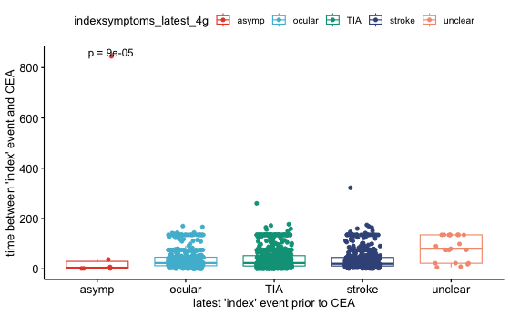

```r
ggpubr::ggboxplot(AEDB.CEA %>% filter(!is.na(indexsymptoms_latest_4g)),
                  x = c("indexsymptoms_latest_4g"),
                  y = "TimeOR_latest4G",
                  xlab = "latest 'index' event prior to CEA",
                  ylab = "time between 'index' event and CEA",
                  color = "indexsymptoms_latest_4g",
                  palette = "npg",
                  add = "jitter") +
  stat_compare_means(aes(group = indexsymptoms_latest_4g), label = "p.format", method = "kruskal.test")
```

## ExpressScan - CONVOCALS sample list

Here we create the CONVOCALS sample list to match/cross reference with the whole-slide images. This includes:

- sampleID = STUDY_NUMBER
- gender

```r
library(data.table)
require(labelled)
CONVOCALS.samplelist.withduplicates <- subset(AEDB.CEA, select =
                                                c("STUDY_NUMBER", "UPID", "informedconsent", "Hospital",
                                                  "Artery_summary", "arteryop", "ORyear",
                                                  "Gender", "Age", "Date.of.birth",
                                                  "TC_final", "LDL_final", "HDL_final", "TG_final",
                                                  "systolic", "diastoli", "GFR_MDRD", "BMI",
                                                  "KDOQI", "BMI_WHO",
                                                  "SmokerStatus", "AlcoholUse",
                                                  "DiabetesStatus",
                                                  "Hypertension.selfreport", "Hypertension.selfreportdrug", "Hypertension.composite", "Hypertension.drugs",
                                                  "Med.anticoagulants", "Med.all.antiplatelet", "Med.Statin.LLD",
                                                  "Stroke_Dx",
                                                  "restenos", "stenose",
                                                  "CAD_history", "PAOD", "Peripheral.interv",
                                                  "MAC_rankNorm", "SMC_rankNorm", "Macrophages.bin", "SMC.bin",
                                                  "Neutrophils_rankNorm", "MastCells_rankNorm",
                                                  "IPH.bin", "VesselDensity_rankNorm",
                                                  "Calc.bin", "Collagen.bin",
                                                  "Fat.bin_10", "Fat.bin_40",
                                                  "OverallPlaquePhenotype", "Plaque_Vulnerability_Index",
                                                  "EP_composite", "EP_composite_time", "EP_major", "EP_major_time",
                                                  "sympt", "AsymptSympt", "AsymptSympt2G",  "Symptoms.5G",
                                                  "indexsymptoms_latest_4g", "Symptoms.Update2G", "Symptoms.Update3G", "TimeOR_latest4G") # new symptom-categories
                                              )

CONVOCALS.samplelist.withduplicates$arteryop <- to_factor(CONVOCALS.samplelist.withduplicates$arteryop)
# library(DT)
# DT::datatable(CONVOCALS.samplelist.withduplicates)
```

### Samples vs. individuals

The AE is using `STUDY_NUMBER` to mark each *individual sample*, but `UPID` numbers are used for each *individual patient*. The latter is important for studies involving, for example genetic data, or in this case predictions.

Here we assess how many UPIDs there are in the sample-list and how many of these are ‘duplicate’, *i.e.* how many patients had multiple surgeries. Next, we randomly select one of each ‘multiple’ UPID.

The general flow is:

- Select samples and store in a dataset `CONVOCALS.samplelist.withduplicates`
- Randomly select 1 sample from `CONVOCALS.samplelist.withduplicates` based on UPIDs
- Create new dataset `CONVOCALS.samplelist`

```r
# what is the damage?

n_occur1 <- as.data.frame(table(CONVOCALS.samplelist.withduplicates$UPID))
dim(n_occur1)
```

```
[1] 2461    2
```

```r
n_occur1a <- n_occur1[n_occur1$Freq>1,]
rm(n_occur1)
n_occur1a
```

|  | Var1 | Freq |
| --- | --- | --- |
| 6 | UPID00010 | 2 |
| 19 | UPID00035 | 2 |
| 30 | UPID00055 | 2 |
| 31 | UPID00057 | 2 |
| 40 | UPID00073 | 2 |
| 53 | UPID00101 | 2 |
| 54 | UPID00102 | 2 |
| 59 | UPID00117 | 2 |
| 64 | UPID00128 | 2 |
| 67 | UPID00132 | 2 |

[output cut: 111 more lines]

```r
# function to filter
# reference: https://stackoverflow.com/questions/23084509/function-for-sampling-between-duplicated-values-in-data-frame
# this is not randomly picking one sample
# filter_data <- function(DATA){
#   distinct_points <- unique(DATA$UPID)
#   as.data.frame(t(sapply(distinct_points, function(x){subset(DATA, UPID == x)[1,]})))
# }
#
# CONVOCALS.samplelist <- filter_data(CONVOCALS.samplelist.withduplicates)

# Reference: https://stackoverflow.com/questions/45804730/randomly-remove-duplicated-rows-using-dplyr

library(dplyr)
set.seed(9192202)
CONVOCALS.samplelist <- CONVOCALS.samplelist.withduplicates %>%
  group_by(UPID) %>%
  sample_n(1)
```

```r
fwrite(CONVOCALS.samplelist,
       file = paste0(OUT_loc, "/", Today, ".CONVOCALS.samplelist.csv"),
       quote = TRUE,
       sep = ",",
       na = "NA",
       row.names = FALSE,
       col.names = TRUE,
       showProgress = TRUE)
```

# Merge with stains

## EVG samples

```r
EVG_slides <- openxlsx::read.xlsx(paste0(STAINS_loc, "/20231023_STAINS_on_HPC.xlsx"),
                                      sheet = "EVG",
                                      colNames = TRUE)
EVG_slides$Order <- NULL
head(EVG_slides)
```

|  | FileName | FileType | STUDY_NUMBER | T_NUMBER | T_NUMBER_ADD | SCAN_DATE_CODE | STAIN |
| --- | --- | --- | --- | --- | --- | --- | --- |
| 1 | AE1001.EVG.ndpi | ndpi | 1001 | NA | NA | NA | EVG |
| 2 | AE1004.EVG.TIF | TIF | 1004 | NA | NA | NA | EVG |
| 3 | AE100.T02-21440.EVG.TIF | TIF | 100 | T02-21440 | NA | NA | EVG |
| 4 | AE1010.EVG.ndpi | ndpi | 1010 | NA | NA | NA | EVG |
| 5 | AE1011.EVG.ndpi | ndpi | 1011 | NA | NA | NA | EVG |
| 6 | AE1012.EVG.ndpi | ndpi | 1012 | NA | NA | NA | EVG |

```r
NA
```

```r
CONVOCALS.samplelist.EVG <- merge(CONVOCALS.samplelist, EVG_slides, by.x = "STUDY_NUMBER", by.y = "STUDY_NUMBER", all.x = TRUE)
```

```r
table(CONVOCALS.samplelist.EVG$STAIN, useNA = "ifany")
```

```
 EVG <NA>
2259  219
```

```r
table(CONVOCALS.samplelist.EVG$FileType, useNA = "ifany")
```

```
ndpi  TIF <NA>
1327  932  219
```

```r
table(CONVOCALS.samplelist.EVG$indexsymptoms_latest_4g, useNA = "ifany")
```

```
  asymp  ocular     TIA  stroke unclear    <NA>
    672     428     769     532      76       1
```

```r
table(CONVOCALS.samplelist.EVG$Symptoms.Update3G, useNA = "ifany")
```

```
Asymptomatic  Symptomatic      Unclear         <NA>
         672         1729           76            1
```

```r
table(CONVOCALS.samplelist.EVG$Artery_summary, useNA = "ifany")
```

```
No artery known (yet), no surgery (patient ill, died, exited study), re-numbered to AAA                                                                  carotid (left & right)
                                                                                      0                                                                                    2443
                                              femoral/iliac (left, right or both sides)                                               other carotid arteries (common, external)
                                                                                      0                                                                                      35
                                  carotid bypass and injury (left, right or both sides)                                                         aneurysmata (carotid & femoral)
                                                                                      0                                                                                       0
                                                                                  aorta                                            other arteries (renal, popliteal, vertebral)
                                                                                      0                                                                                       0
                       femoral bypass, angioseal and injury (left, right or both sides)
                                                                                      0
```

```r
fwrite(subset(CONVOCALS.samplelist.EVG, is.na(STAIN)),
       file = paste0(OUT_loc, "/", Today, ".CONVOCALS.samplelist.noEVGslides.csv"),
       quote = TRUE,
       sep = ",",
       na = "NA",
       row.names = FALSE,
       col.names = TRUE,
       showProgress = TRUE)

fwrite(CONVOCALS.samplelist.EVG,
       file = paste0(OUT_loc, "/", Today, ".CONVOCALS.samplelist.withEVGslides.csv"),
       quote = TRUE,
       sep = ",",
       na = "NA",
       row.names = FALSE,
       col.names = TRUE,
       showProgress = TRUE)
```

```r
hs <- openxlsx::createStyle(
  textDecoration = "BOLD"
)
openxlsx::write.xlsx(CONVOCALS.samplelist.EVG,
       file = paste0(OUT_loc, "/", Today, ".CONVOCALS.samplelist.withEVGslides.xlsx"),
       overwrite = TRUE,
       sheetName = "EVG_SampleList",
       tabColour = uithof_color[16],
       creator = "Sander W. van der Laan",
       headerStyle = hs,
       keepNA = TRUE, na.string = "NA")
```

> Note: we have 17 samples where there are two pieces of the segments, or there are two scans. These are: - 292 UPID00725 AE292.EVG.TIF - 292 UPID00725 AE292.EVG.v2.ndpi - 297 UPID00329 AE297.EVG.TIF - 297 UPID00329 AE297.EVG.v2.ndpi - 300 UPID01807 AE300.EVG.TIF - 300 UPID01807 AE300.T03-24318.EVG.v2.ndpi - 363 UPID00682 AE363.T04-09070.EVG.B.ndpi - 363 UPID00682 AE363.T04-09070.EVG.A.ndpi - 926 UPID00593 AE926.EVG.TIF - 926 UPID00593 AE926.T05-10375.EVG.v2.ndpi - 1565 UPID00947 AE1565.T07-14473.EVG.v2.ndpi - 1565 UPID00947 AE1565.EVG.TIF - 1645 UPID00700 AE1645.T07-10464.EVG.v2.ndpi - 1645 UPID00700 AE1645.EVG.TIF - 1671 UPID00420 AE1671.EVG.TIF - 1671 UPID00420 AE1671.T07-15965.EVG.v2.ndpi - 1672 UPID00688 AE1672.T07-15706.EVG.v2.ndpi - 1672 UPID00688 AE1672.EVG.TIF - 1676 UPID00083 AE1676.T07-13742.EVG.v2.ndpi - 1676 UPID00083 AE1676.EVG.TIF - 1811 UPID01881 AE1811.T07-14002.EVG.v2.ndpi - 1811 UPID01881 AE1811.EVG.TIF - 2039 UPID01975 AE2039.T08-20781.EVG.v2.ndpi - 2039 UPID01975 AE2039.EVG.TIF - 2040 UPID01976 AE2040.EVG.TIF - 2040 UPID01976 AE2040.T08-20757.EVG.v2.ndpi - 2083 UPID02217 AE2083.EVG.TIF - 2083 UPID02217 AE2083.T09-16562.EVG.v2.ndpi - 2289 UPID02336 AE2289.EVG.v2.ndpi - 2289 UPID02336 AE2289.EVG.TIF - 2298 UPID02363 AE2298.EVG.v2.ndpi - 2298 UPID02363 AE2298.EVG.TIF - 2343 UPID00927 AE2343.T09-31738.EVG.v2.ndpi - 2343 UPID00927 AE2343.EVG.TIF

> We need to choose which samples to use.

## HE samples

```r
HE_slides <- openxlsx::read.xlsx(paste0(STAINS_loc, "/20231023_STAINS_on_HPC.xlsx"),
                                      sheet = "HE",
                                      colNames = TRUE)
HE_slides$Order <- NULL
head(HE_slides)
```

|  | FileName | FileType | STUDY_NUMBER | T_NUMBER | T_NUMBER_ADD | SCAN_DATE_CODE | STAIN |
| --- | --- | --- | --- | --- | --- | --- | --- |
| 1 | AE1.T02-5340.A.HE.TIF | TIF | 1 | T02-5340 | A | NA | HE |
| 2 | AE1.T02-5340.B.HE.TIF | TIF | 1 | T02-5340 | B | NA | HE |
| 3 | AE9.T02-7170.HE.ndpi | ndpi | 9 | T02-7170 | NA | NA | HE |
| 4 | AE11.T02-7271.HE.ndpi | ndpi | 11 | T02-7271 | NA | NA | HE |
| 5 | AE12.T02-7979.HE.ndpi | ndpi | 12 | T02-7979 | NA | NA | HE |
| 6 | AE13.T02-6923.HE.TIF | TIF | 13 | T02-6923 | NA | NA | HE |

```r
NA
```

```r
CONVOCALS.samplelist.HE <- merge(CONVOCALS.samplelist, HE_slides, by.x = "STUDY_NUMBER", by.y = "STUDY_NUMBER", all.x = TRUE)
```

```r
table(CONVOCALS.samplelist.HE$STAIN, useNA = "ifany")
```

```
  HE <NA>
2227  237
```

```r
table(CONVOCALS.samplelist.HE$FileType, useNA = "ifany")
```

```
ndpi  TIF <NA>
1108 1119  237
```

```r
table(CONVOCALS.samplelist.HE$indexsymptoms_latest_4g, useNA = "ifany")
```

```
  asymp  ocular     TIA  stroke unclear    <NA>
    668     426     768     528      73       1
```

```r
table(CONVOCALS.samplelist.HE$Symptoms.Update3G, useNA = "ifany")
```

```
Asymptomatic  Symptomatic      Unclear         <NA>
         668         1722           73            1
```

```r
table(CONVOCALS.samplelist.HE$Artery_summary, useNA = "ifany")
```

```
No artery known (yet), no surgery (patient ill, died, exited study), re-numbered to AAA                                                                  carotid (left & right)
                                                                                      0                                                                                    2429
                                              femoral/iliac (left, right or both sides)                                               other carotid arteries (common, external)
                                                                                      0                                                                                      35
                                  carotid bypass and injury (left, right or both sides)                                                         aneurysmata (carotid & femoral)
                                                                                      0                                                                                       0
                                                                                  aorta                                            other arteries (renal, popliteal, vertebral)
                                                                                      0                                                                                       0
                       femoral bypass, angioseal and injury (left, right or both sides)
                                                                                      0
```

```r
fwrite(subset(CONVOCALS.samplelist.HE, is.na(STAIN)),
       file = paste0(OUT_loc, "/", Today, ".CONVOCALS.samplelist.noHEslides.csv"),
       quote = TRUE,
       sep = ",",
       na = "NA",
       row.names = FALSE,
       col.names = TRUE,
       showProgress = TRUE)

fwrite(CONVOCALS.samplelist.HE,
       file = paste0(OUT_loc, "/", Today, ".CONVOCALS.samplelist.withHEslides.csv"),
       quote = TRUE,
       sep = ",",
       na = "NA",
       row.names = FALSE,
       col.names = TRUE,
       showProgress = TRUE)
```

```r
hs <- openxlsx::createStyle(
  textDecoration = "BOLD"
)
openxlsx::write.xlsx(CONVOCALS.samplelist.HE,
       file = paste0(OUT_loc, "/", Today, ".CONVOCALS.samplelist.withHEslides.xlsx"),
       overwrite = TRUE,
       sheetName = "HE_SampleList",
       tabColour = uithof_color[16],
       creator = "Sander W. van der Laan",
       headerStyle = hs,
       keepNA = TRUE, na.string = "NA")
```

> Note: we have 3 samples where there are two pieces of the segments. These are: - 1 UPID90067 AE1.T02-5340.B.HE.TIF AE1.T02-5340.A.HE.TIF - 363 UPID00682 AE363.T04-09070.HE.B.ndpi AE363.T04-09070.HE.A.ndpi - 921 UPID01421 AE921.T05-16731.HE.A.ndpi AE921.T05-16731.HE.B.ndpi

## SMA samples

```r
SMA_slides <- openxlsx::read.xlsx(paste0(STAINS_loc, "/20231023_STAINS_on_HPC.xlsx"),
                                      sheet = "SMA",
                                      colNames = TRUE)
SMA_slides$Order <- NULL
# SMA_slides.raw[, "Slides" := "SMA"]
# names(SMA_slides.raw)[names(SMA_slides.raw) == "study_number_only"] <- "STUDY_NUMBER"
# head(SMA_slides.raw)
# library(dplyr)
# library(stringr)
# SMA_slides <- SMA_slides.raw %>%
#   mutate(across('STUDY_NUMBER', str_replace, 'AE', ''))
head(SMA_slides)
```

|  | FileName | FileType | STUDY_NUMBER | T_NUMBER | T_NUMBER_ADD | SCAN_DATE_CODE | STAIN |
| --- | --- | --- | --- | --- | --- | --- | --- |
| 1 | AE1.T02-5340.SMA.20141128.ndpi | ndpi | 1 | T02-5340 | NA | 20141128 | SMA |
| 2 | AE2.T02-5684.SMA.20141128.TIF | TIF | 2 | T02-5684 | NA | 20141128 | SMA |
| 3 | AE5.T02-6890.SMA.20141128.TIF | TIF | 5 | T02-6890 | NA | 20141128 | SMA |
| 4 | AE9.T02-7170.SMA.20141128.TIF | TIF | 9 | T02-7170 | NA | 20141128 | SMA |
| 5 | AE11.T02-7271.SMA.20141128.TIF | TIF | 11 | T02-7271 | NA | 20141128 | SMA |
| 6 | AE13.T02-6923.SMA.20141128.TIF | TIF | 13 | T02-6923 | NA | 20141128 | SMA |

```r
# rm(SMA_slides.raw)
```

```r
CONVOCALS.samplelist.SMA <- merge(CONVOCALS.samplelist, SMA_slides, by.x = "STUDY_NUMBER", by.y = "STUDY_NUMBER", all.x = TRUE)
```

```r
table(CONVOCALS.samplelist.SMA$STAIN, useNA = "ifany")
```

```
 SMA <NA>
2183  278
```

```r
table(CONVOCALS.samplelist.SMA$FileType, useNA = "ifany")
```

```
ndpi  TIF <NA>
 668 1515  278
```

```r
table(CONVOCALS.samplelist.SMA$indexsymptoms_latest_4g, useNA = "ifany")
```

```
  asymp  ocular     TIA  stroke unclear    <NA>
    667     426     766     528      73       1
```

```r
table(CONVOCALS.samplelist.SMA$Symptoms.Update3G, useNA = "ifany")
```

```
Asymptomatic  Symptomatic      Unclear         <NA>
         667         1720           73            1
```

```r
table(CONVOCALS.samplelist.SMA$Artery_summary, useNA = "ifany")
```

```
No artery known (yet), no surgery (patient ill, died, exited study), re-numbered to AAA                                                                  carotid (left & right)
                                                                                      0                                                                                    2426
                                              femoral/iliac (left, right or both sides)                                               other carotid arteries (common, external)
                                                                                      0                                                                                      35
                                  carotid bypass and injury (left, right or both sides)                                                         aneurysmata (carotid & femoral)
                                                                                      0                                                                                       0
                                                                                  aorta                                            other arteries (renal, popliteal, vertebral)
                                                                                      0                                                                                       0
                       femoral bypass, angioseal and injury (left, right or both sides)
                                                                                      0
```

```r
fwrite(subset(CONVOCALS.samplelist.SMA, is.na(STAIN)),
       file = paste0(OUT_loc, "/", Today, ".CONVOCALS.samplelist.noSMAslides.csv"),
       quote = TRUE,
       sep = ",",
       na = "NA",
       row.names = FALSE,
       col.names = TRUE,
       showProgress = TRUE)

fwrite(CONVOCALS.samplelist.SMA,
       file = paste0(OUT_loc, "/", Today, ".CONVOCALS.samplelist.withSMAslides.csv"),
       quote = TRUE,
       sep = ",",
       na = "NA",
       row.names = FALSE,
       col.names = TRUE,
       showProgress = TRUE)
```

```r
hs <- openxlsx::createStyle(
  textDecoration = "BOLD"
)
openxlsx::write.xlsx(CONVOCALS.samplelist.SMA,
       file = paste0(OUT_loc, "/", Today, ".CONVOCALS.samplelist.withSMAslides.xlsx"),
       overwrite = TRUE,
       sheetName = "SMA_SampleList",
       tabColour = uithof_color[16],
       creator = "Sander W. van der Laan",
       headerStyle = hs,
       keepNA = TRUE, na.string = "NA")
```

# Session information

```
Version:      v1.0.8
Last update:  2023-10-23
Written by:   Sander W. van der Laan (s.w.vanderlaan-2[at]umcutrecht.nl).
Description:  Script to get some Athero-Express Biobank Study baseline characteristics.
Minimum requirements: R version 4.3.1 (2023-06-16) -- "Beagle Scouts", Mac OS X Sonoma (14.0, beta 5, 23A5312d)

**MoSCoW To-Do List**
The things we Must, Should, Could, and Would have given the time we have.
_M_

_S_

_C_

_W_

**Changes log**
* v1.0.8 Added EVG files, type, filename, and stain information.
* v1.0.7 Check presence SMA and HE files, including type, filename, and stain. Added Excel-export.
* v1.0.6 Added time-to-event analysis with respect to symptoms. Add this to the output table.
* v1.0.5 Added new SMA slides. Added baseline characteristics data.
* v1.0.4 Updated AE database. Output includes IPH. Created list of samples without SMA slides.
* v1.0.3 Updated AE database. Added function to randomly select multiplicate UPIDs.
* v1.0.2 Simplified the initial script. It now outputs the relevant R-objects (as .RDS).
* v1.0.1 Update to main AEDB (there is an error in the Age-variable in the new version).
* v1.0.0 Initial version. Add 'plaque vulnerability index', Fixed baseline table, added codes, and results. Major update to WORCS system.
```

# Saving environment

```r
save.image(paste0(PROJECT_loc, "/",Today,".",PROJECTNAME,".AEDB.CEA.baseline.RData"))
```

| <sup>© 1979-2022 Sander W. van der Laan \| s.w.vanderlaan[at]gmail.com \| swvanderlaan.github.io.</sup> |
| --- |